# Two Years of Bayesian Bandits for E-Commerce

[figure not shown]

### Data Philly • April 2, 2018 • [@AustinRochford](https://twitter.com/AustinRochford)

### About Me

#### Principal Data Scientist and Director of [Monetate Labs](http://www.monetate.com/)

#### [@AustinRochford](https://twitter.com/AustinRochford) • austinrochford.com • github.com/AustinRochford

#### arochford@monetate.com • austin.rochford@gmail.com

### About Monetate

- Founded 2008, web optimization and personalization SaaS
- Observed 5B impressions and $4.1B in revenue during Cyber Week 2017

#### Nontechnical marketer-focused

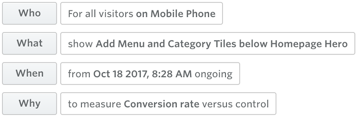

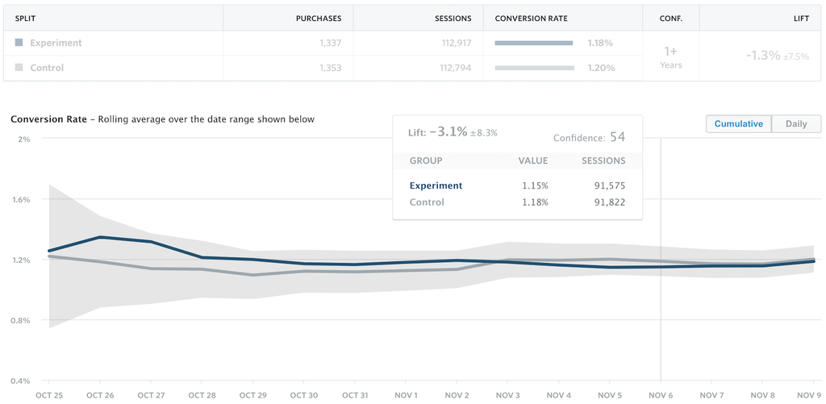

[figure not shown]

monetate.com/about/careers

### About this talk

### Outline

- Web optimization
  - A/B testing
  - Multi-armed bandits
- Bayesian bandits
  - Thompson sampling
- Nonstationarity
  - Kalman filters
  - Decayed posteriors
- Bandit bias
  - Inverse propensity weighting
- Contextual bandits?

## Web Optimization

[figure not shown]

### A/B testing

[figure not shown]

#### A/B testing machinery

| Ronald Fisher | Abraham Wald |  |
| --- | --- | --- |

### Multi-armed bandits

[figure not shown]

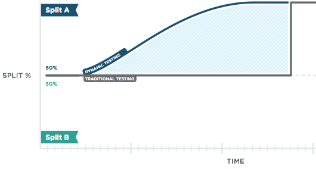

#### Multi-armed bandit systems

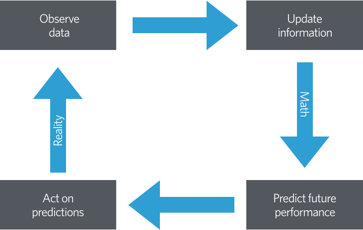

## Bayesian Bandits

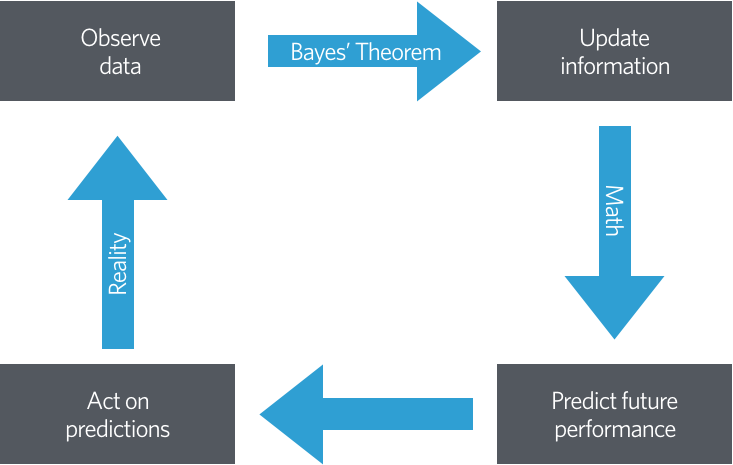

### Beta-binomial model

$$ \begin{align*} x_A, x_B & = \textrm{number of rewards from users shown variant } A, B \\ x_A & \sim \textrm{Binomial}(n_A, r_A) \\ x_B & \sim \textrm{Binomial}(n_B, r_B) \\ r_A, r_B & \sim \textrm{Beta}(1, 1) \end{align*} $$

$$ \begin{align*} r_A\ |\ n_A, x_A & \sim \textrm{Beta}(x_A + 1, n_A - x_A + 1) \\ r_B\ |\ n_B, x_B & \sim \textrm{Beta}(x_B + 1, n_B - x_B + 1) \end{align*} $$

### Thompson sampling

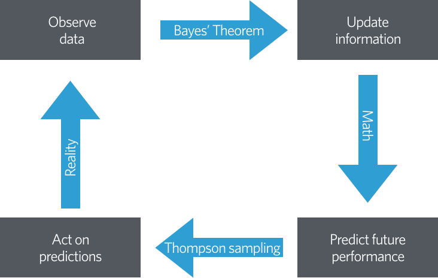

*Thompson sampling* randomizes user/variant assignment according to the probabilty that each variant maximizes the posterior expected reward.

The probability that a user is assigned variant A is

$$ \begin{align*} P(r_A > r_B\ |\ \mathcal{D}) & = \int_0^1 P(r_A > r\ |\ \mathcal{D})\ \pi_B(r\ |\ \mathcal{D})\ dr \\ & = \int_0^1 \left(\int_r^1 \pi_A(s\ |\ \mathcal{D})\ ds\right)\ \pi_B(r\ |\ \mathcal{D})\ dr \\ & \propto \int_0^1 \left(\int_r^1 s^{\alpha_A - 1} (1 - s)^{\beta_A - 1}\ ds\right) r^{\alpha_B - 1} (1 - r)^{\beta_B - 1}\ dr \end{align*} $$

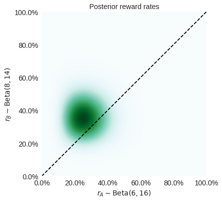

```python
fig
```

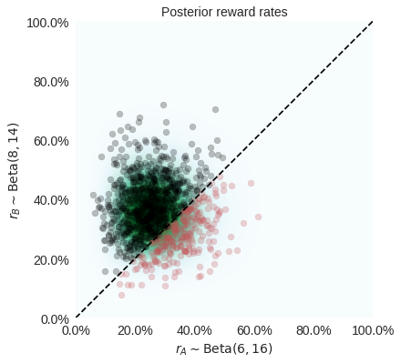

```python
fig
```

```python
(a_samples > b_samples).mean()
```

```
0.24299999999999999
```

#### Thompson sampling, redeemed

1. Sample $\hat{r}_A \sim r_A\ |\ n_A, x_A$ and $\hat{r}_B \sim r_B\ |\ n_B, x_B$.
2. Assign the user variant A if $\hat{r}_A > \hat{r}_B$, otherwise assign them variant B.

#### Simulating a bandit

```python
class BetaBinomial:
    def __init__(self, a0=1., b0=1.):
        self.a = a0
        self.b = b0

    def sample(self):
        return sp.stats.beta.rvs(self.a, self.b)

    def update(self, n, x):
        self.a += x
        self.b += n - x
```

```python
class Bandit:
    def __init__(self, a_post, b_post):
        self.a_post = a_post
        self.b_post = b_post

    def assign(self):
        return 1 * (self.a_post.sample() < self.b_post.sample())

    def update(self, arm, reward):
        arm_post = self.a_post if arm == 0 else self.b_post
        arm_post.update(1, reward)
```

```python
A_RATE, B_RATE = 0.05, 0.1
N = 1000

rewards_gen = generate_rewards(A_RATE, B_RATE, N)
```

```python
bandit = Bandit(BetaBinomial(), BetaBinomial())
arms = np.empty(N, dtype=np.int64)
rewards = np.empty(N)

for t, arm_rewards in tqdm(enumerate(rewards_gen), total=N):
    arms[t] = bandit.assign()
    rewards[t] = arm_rewards[arms[t]]

    bandit.update(arms[t], rewards[t])
```

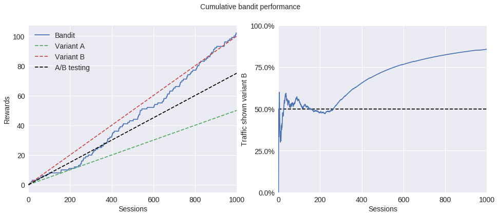

```python
fig
```

#### Simulating many bandits

```python
N_BANDIT = 100

arms = np.empty((N_BANDIT, N), dtype=np.int64)
rewards = np.empty((N_BANDIT, N))

for i in trange(N_BANDIT):
    arms[i], rewards[i] = simulate_bandit(
        generate_rewards(A_RATE, B_RATE, N), N
    )
```

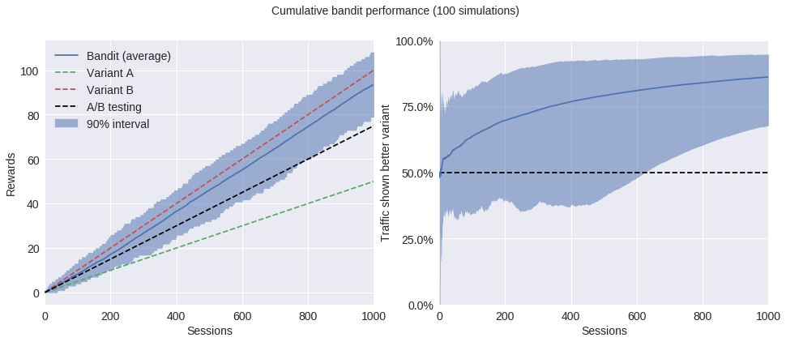

```python
fig
```

### A/A testing

[figure not shown]

##### A/A bandits

```python
N = 2000

arms, rewards = simulate_bandits(
    lambda: generate_rewards(A_RATE, A_RATE, N),
    N, N_BANDIT
)
```

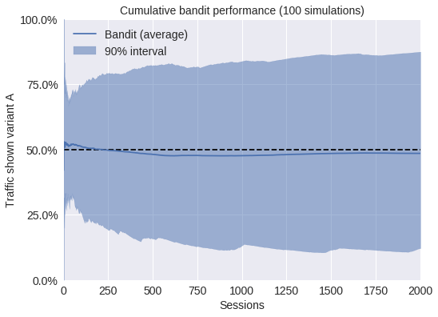

```python
fig
```

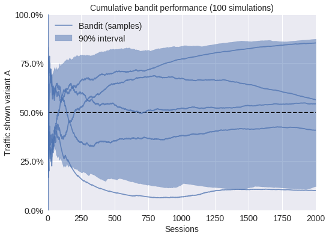

```python
fig
```

### Why Bayesian?

- Thompson sampling is [intuitive](https://en.wikipedia.org/wiki/Probability_matching) and simple to implement
- Principled randomization
  - Robustness against [delayed feedback](https://papers.nips.cc/paper/4321-an-empirical-evaluation-of-thompson-sampling.pdf)
- Marketers are natural Bayesians!

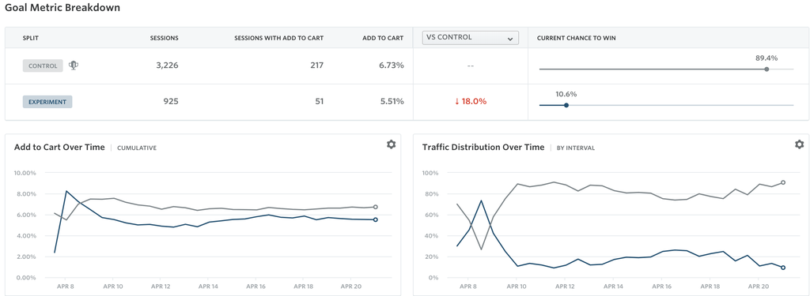

## Nonstationarity

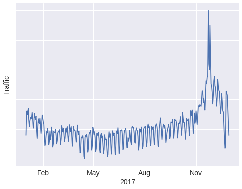

```python
fig
```

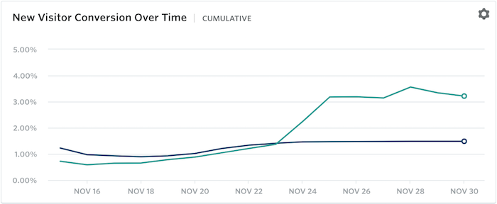

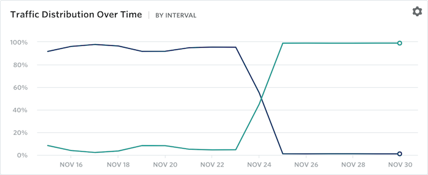

### Kalman filters

[figure not shown]

### Decaying evidence

#### Bayes theorem

$$\pi_{t + 1}(\theta\ |\ \mathcal{D}_{t + 1}, \mathcal{D}_{1, t}) \propto \color{blue}{\underbrace{f(\mathcal{D}_{t + 1}\ |\ \theta)}_{\textrm{likelihood}}} \cdot \color{red}{\underbrace{\pi_{t}(\theta\ |\ \mathcal{D}_{1,t})}_{\textrm{posterior after time } t}}$$

#### Decayed posterior

For $0 < \varepsilon \ll 1$

$$\color{purple}{\underbrace{\tilde{\pi}_{t + 1}(\theta\ |\ \mathcal{D}_{t + 1}, \mathcal{D}_{1, t})}_{\textrm{decayed posterior after time } t + 1}} \propto \left(\color{blue}{f(\mathcal{D}_{t + 1}\ |\ \theta)} \cdot \tilde{\color{red}{\pi}}_{\color{red}{t}}\color{red}{(\theta\ |\ \mathcal{D}_{1,t})}\right)^{1 - \varepsilon} \cdot \color{green}{\underbrace{\pi_0(\theta)}_{\textrm{no-data prior}}}^{\varepsilon}$$

If we stop collecting data at time $T$,

$$\color{purple}{\tilde{\pi}_{t}(\theta\ |\ \mathcal{D}_{1, T})} \overset{t \to \infty}{\longrightarrow} \color{green}{\pi_0(\theta)}.$$

#### Decayed beta-Binomial

If

$$ \begin{align*} \color{green}{\pi_0(r)} & = \textrm{Beta}(\alpha_0, \beta_0) \\ \color{purple}{\tilde{\pi}_t(r\ |\ \mathcal{D}_{1, t})} & = \textrm{Beta}(\alpha_t, \beta_t) \end{align*} $$

and no data is observed at time $t + 1$, then

$$\color{purple}{\tilde{\pi}_{t + 1}(r\ |\ \mathcal{D}_{t + 1} = \emptyset, \mathcal{D}_{1, t})} = \textrm{Beta}((1 - \varepsilon) \alpha_t + \varepsilon \alpha_0, (1 - \varepsilon) \beta_t + \varepsilon \beta_0).$$

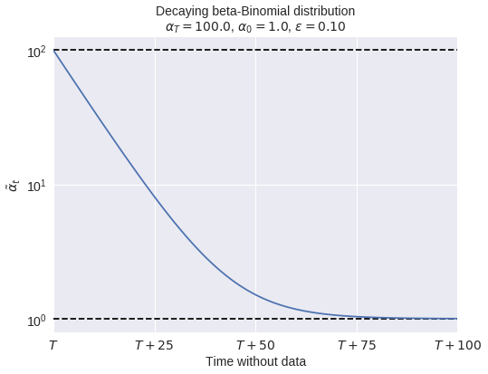

```python
fig
```

```python
class DecayedBetaBinomial(BetaBinomial):
    def __init__(self, eps, a0=1., b0=1.):
        super(DecayedBetaBinomial, self).__init__(a0=a0, b0=b0)

        self.eps = eps
        self.a0 = a0
        self.b0 = b0

    def update(self, n, x):
        super(DecayedBetaBinomial, self).update(n, x)

        self.a = (1 - self.eps) * self.a + self.eps * self.a0
        self.b = (1 - self.eps) * self.b + self.eps * self.b0
```

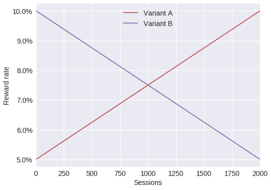

```python
fig
```

```python
arms, rewards = simulate_bandits(
    lambda: generate_changing_rewards(A_RATES, B_RATES, N),
    N, N_BANDIT,
)

decay_arms, decay_rewards = simulate_bandits(
    lambda: generate_changing_rewards(A_RATES, B_RATES, N),
    N, N_BANDIT,
    prior=lambda: DecayedBetaBinomial(0.01)
)
```

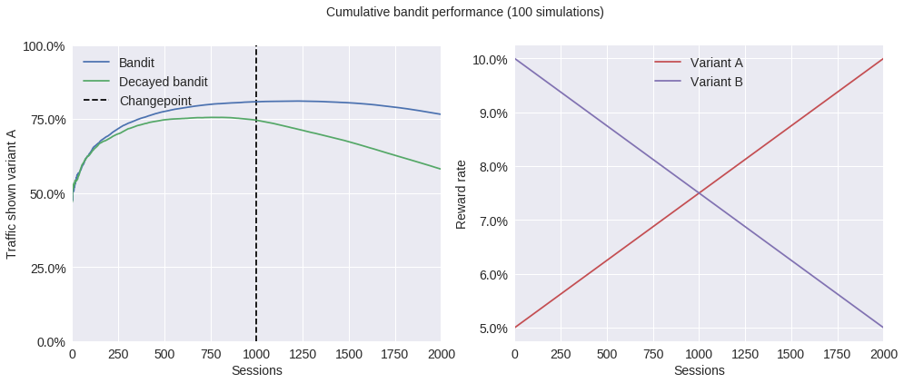

```python
fig
```

## Bandit Bias

[figure not shown]

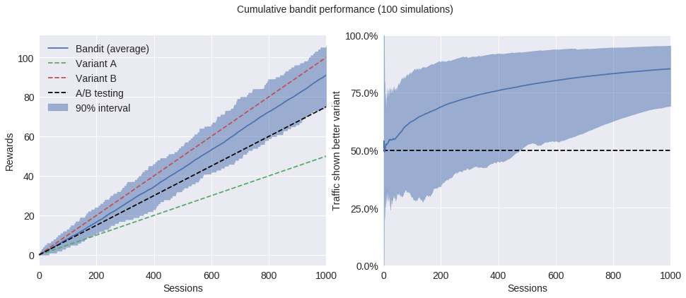

```python
fig
```

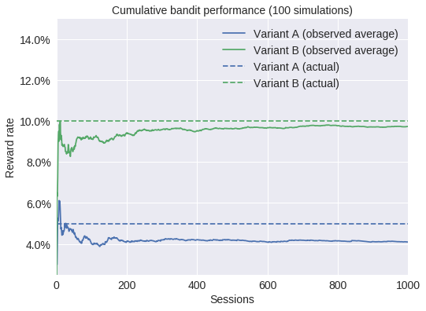

```python
fig
```

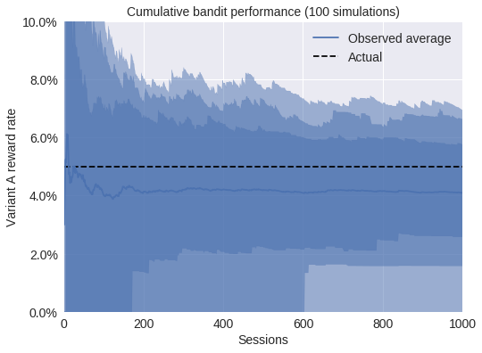

```python
fig
```

[figure not shown]

### Inverse propensity weighting

$$ \hat{r}^{\textrm{IPS}}_A = \frac{1}{n} \sum_{t = 1}^n \frac{Y_i \cdot \mathbb{I}(A_t = 1)}{P(A_t = 1\ |\ \mathcal{D}_{1, t - 1})} $$

where

$$ A_t = \begin{cases} 1 & \textrm{session } t \textrm{ saw variant A} \\ 0 & \textrm{session } t \textrm{ saw variant B} \end{cases}. $$

**Calculating** $P(A_t = 1\ |\ \mathcal{D}_{1, t - 1})$

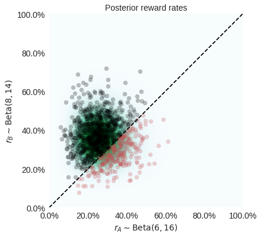

```python
ts_fig
```

```python
%%time
N_MC = 500

a_samples = sp.stats.beta.rvs(
    a_post_alpha[..., np.newaxis],
    a_post_beta[..., np.newaxis],
    size=(N_BANDIT, N, N_MC)
)
b_samples = sp.stats.beta.rvs(
    b_post_alpha[..., np.newaxis],
    b_post_beta[..., np.newaxis],
    size=(N_BANDIT, N, N_MC)
)

a_prob = np.empty((N_BANDIT, N))
a_prob[:, 0] = 0.5
a_prob[:, 1:] = (a_samples > b_samples).mean(axis=2)[:, :-1]
```

```
CPU times: user 22.4 s, sys: 3.17 s, total: 25.6 s
Wall time: 25.9 s
```

```python
a_ips_est = 1. / plot_t * (rewards * (arms == 0) / a_prob_).cumsum(axis=1)
b_ips_est = 1. / plot_t * (rewards * (arms == 1) / (1 - a_prob_)).cumsum(axis=1)
```

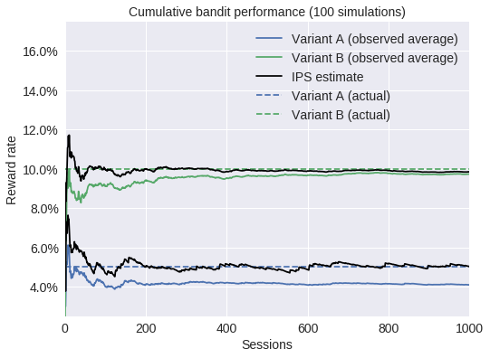

```python
fig
```

### Bias-variance tradeoff

[figure not shown]

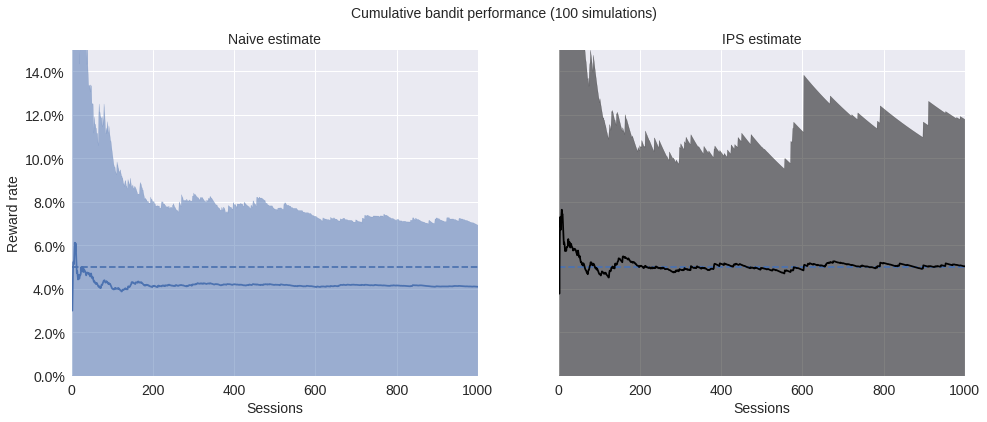

```python
fig
```

**Intuition:** the variant with the highest reward rate should receive the most traffic.

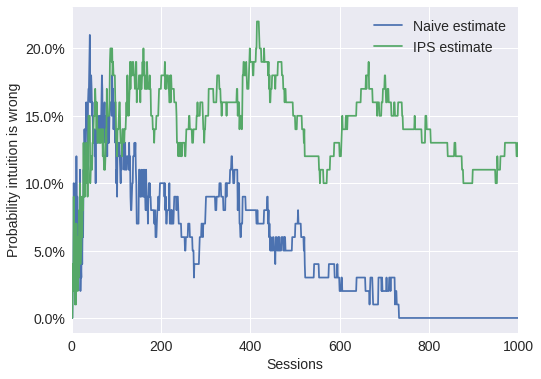

```python
fig
```

## Contextual Bandits

### Challenges

- Streaming feature engineering
  - Untrusted feature data
- Streaming feature scaling
- Temporally shifting covariates
- Non-conjugate likelihoods
- Interpretability

## Thank You!

|  | monetate.com/about/careers |
| --- | --- |

#### [@AustinRochford](https://twitter.com/AustinRochford) • austinrochford.com • github.com/AustinRochford

#### arochford@monetate.com • austin.rochford@gmail.com